# Storm Analysis

Rob Rolleston

July 26, 2015

## Synopsis

Storms and other severe weather events can cause both public health and economic problems for communities and municipalities. Many severe events can result in fatalities, injuries, and property damage. By examining data from the National Weather Service this study determines that tornadoes are the event that is most harmful with respect to human health (e.g. fatalities & injuries) and that floods have the greatest economic damage to property & crops.

## Data Processing

The raw data is available at [Storm Data](https://d396qusza40orc.cloudfront.net/repdata%2Fdata%2FStormData.csv.bz2).  
The required libraries are loaded, and the data is read from the compressed file into the `stormData` object. For performance, if the `stormData` object exists or the `stormData.Rdata` file exists, these are used.

```r
#Load required libraries
library(data.table, quietly = TRUE, verbose=FALSE, warn.conflicts = FALSE)
library(ggplot2, quietly = TRUE, verbose=FALSE, warn.conflicts = FALSE)
library(dplyr, quietly = TRUE, verbose=FALSE, warn.conflicts = FALSE)

#Load data
if (!exists("stormData")) {
  #print("stormdata object not found")
  if (file.exists("stormData.RData")) {
    #print("stormData.RData file exists")
    load("stormData.RData")
  } else {
    #print ("reading file")
    stormData <- read.csv("repdata_data_StormData.csv.bz2")
    save(stormData, file="stormData.RData")
  }
} else {
  #print("stormdata object exists")
}
```

The data has 902297 entries with 37 measures. For this analysis we need only those measures pertaining to the type of event, as encoded with the `EVTYPE` measure where there was was harm to human health or economic consequences. By examining the data, and the documentation at

- National Weather Service [Storm Data Documentation](https://d396qusza40orc.cloudfront.net/repdata%2Fpeer2_doc%2Fpd01016005curr.pdf)
- National Climatic Data Center Storm Events [FAQ](https://d396qusza40orc.cloudfront.net/repdata%2Fpeer2_doc%2FNCDC%20Storm%20Events-FAQ%20Page.pdf)

The relevant measures for each question were determined to be:

- harmful with respect to population health
  - FATALITIES, INJURIES
- greatest economic consequences
  - PROPDMG (and PROPDMGEXP), CROPDMG, (and CROPDMGEXP)

For ease of processing, the data frame was converted it a `dplyr` df object `stormData_df`, using only the relevant measures, and only the rows with a non-zero value for one of the measures of interest. At this point the data set was also split into two data sets:

- `stormDataH` for the rows with non-zeros Human Impact
- `stormDataE` for the rows with non-zeros Economic Impact

```r
stormDataH <- tbl_df(stormData) %>%
  select(one_of(c("EVTYPE", "FATALITIES", "INJURIES"))) %>%
  filter(FATALITIES >0 | INJURIES >0)
stormDataE <- tbl_df(stormData) %>%
  select(one_of(c("EVTYPE", "PROPDMG", "PROPDMGEXP", "CROPDMG", "CROPDMGEXP"))) %>%
  filter(PROPDMG  >0 | CROPDMG  >0 )
```

This Human Impact data set has 21929 rows. and the Economic Impact data set has 245031 rows.

One further piece of processing is required for the Economic Impact data. The PROPDMG and CROPDMG each have the scale of the value encoded in PROPDMGEXP and CROPDMGEXP respectively. These encoding were re-factored, given the subset of rows selected

```r
stormDataE$PROPDMGEXP <- factor(stormDataE$PROPDMGEXP)
stormDataE$CROPDMGEXP <- factor(stormDataE$CROPDMGEXP)
```

The encoding for each are:  
PROP: , -, +, 0, 2, 3, 4, 5, 6, 7, B, h, H, K, m, M  
CROP: , ?, 0, B, k, K, m, M Where the numerical digits are exponents, and the h|H, k|K, m|M, and B specify hundred, thousand, million,and billion. The other markers: ‘-’, ’+“, and ‘?’ are unknown. Fortunately there are very few of these entries PROP: 6  
CROP: 6  
These entries were dropped from the data set

```r
stormDataE <- filter(stormDataE, !(PROPDMGEXP %in% (c('-','+','?'))))
stormDataE <- filter(stormDataE, !(CROPDMGEXP %in% (c('-','+','?'))))
```

The remaining exponent notation were all converted to numerical values, along with the true value of the damage.

```r
stormDataE$PROPEXP[stormDataE$PROPDMGEXP == ""] <- 1
stormDataE$PROPEXP[stormDataE$PROPDMGEXP == "H"] <- 100
stormDataE$PROPEXP[stormDataE$PROPDMGEXP == "h"] <- 100
stormDataE$PROPEXP[stormDataE$PROPDMGEXP == "K"] <- 1000
stormDataE$PROPEXP[stormDataE$PROPDMGEXP == "M"] <- 1e+06
stormDataE$PROPEXP[stormDataE$PROPDMGEXP == "m"] <- 1e+06
stormDataE$PROPEXP[stormDataE$PROPDMGEXP == "B"] <- 1e+09
stormDataE$PROPEXP[stormDataE$PROPDMGEXP == "0"] <- 1
stormDataE$PROPEXP[stormDataE$PROPDMGEXP == "1"] <- 10
stormDataE$PROPEXP[stormDataE$PROPDMGEXP == "2"] <- 100
stormDataE$PROPEXP[stormDataE$PROPDMGEXP == "3"] <- 1000
stormDataE$PROPEXP[stormDataE$PROPDMGEXP == "4"] <- 10000
stormDataE$PROPEXP[stormDataE$PROPDMGEXP == "5"] <- 1e+05
stormDataE$PROPEXP[stormDataE$PROPDMGEXP == "6"] <- 1e+06
stormDataE$PROPEXP[stormDataE$PROPDMGEXP == "7"] <- 1e+07
stormDataE$PROPEXP[stormDataE$PROPDMGEXP == "8"] <- 1e+08
stormDataE$PROPEXP[stormDataE$PROPDMGEXP == "9"] <- 1e+09
# Finally, compute the property damage value
stormDataE$PROPDMGVAL <- 0
stormDataE$PROPDMGVAL <- stormDataE$PROPDMG * stormDataE$PROPEXP

stormDataE$CROPEXP[stormDataE$CROPDMGEXP == ""] <- 1
stormDataE$CROPEXP[stormDataE$CROPDMGEXP == "B"] <- 1e+09
stormDataE$CROPEXP[stormDataE$CROPDMGEXP == "M"] <- 1e+06
stormDataE$CROPEXP[stormDataE$CROPDMGEXP == "m"] <- 1e+06
stormDataE$CROPEXP[stormDataE$CROPDMGEXP == "K"] <- 1000
stormDataE$CROPEXP[stormDataE$CROPDMGEXP == "k"] <- 1000
stormDataE$CROPEXP[stormDataE$CROPDMGEXP == "0"] <- 1
stormDataE$CROPEXP[stormDataE$CROPDMGEXP == "1"] <- 10
stormDataE$CROPEXP[stormDataE$CROPDMGEXP == "2"] <- 100
stormDataE$CROPEXP[stormDataE$CROPDMGEXP == "3"] <- 1000
stormDataE$CROPEXP[stormDataE$CROPDMGEXP == "4"] <- 10000
stormDataE$CROPEXP[stormDataE$CROPDMGEXP == "5"] <- 1e+05
stormDataE$CROPEXP[stormDataE$CROPDMGEXP == "6"] <- 1e+06
stormDataE$CROPEXP[stormDataE$CROPDMGEXP == "7"] <- 1e+07
stormDataE$CROPEXP[stormDataE$CROPDMGEXP == "8"] <- 1e+08
stormDataE$CROPEXP[stormDataE$CROPDMGEXP == "9"] <- 1e+09
# Finally, compute the crop damage value
stormDataE$CROPDMGVAL <- 0
stormDataE$CROPDMGVAL <- stormDataE$CROPDMG * stormDataE$CROPEXP
```

Now that all the values share a common format, the rows can be aggregated by `EVTYPE`, with sums, sorted, and the top 10 of each selected

```r
stormDataHumanByType <- stormDataH %>% group_by(EVTYPE) %>%
  summarise(totalFatalities=sum(FATALITIES), totalInjuries=sum(INJURIES)) %>%
  mutate(totalHuman = totalFatalities + totalInjuries) %>%
  top_n(10, totalHuman) %>%
  arrange(desc(totalHuman))
stormDataHumanByType$EVTYPE <- factor(stormDataHumanByType$EVTYPE)

stormDataEconomicByType <- stormDataE %>% group_by(EVTYPE) %>%
  summarise(totalCrop=sum(CROPDMGVAL), totalProp=sum(PROPDMGVAL)) %>%
  mutate(totalEconomic = totalCrop + totalProp) %>%
  top_n(10, totalEconomic) %>%
  arrange(desc(totalEconomic))
stormDataEconomicByType$EVTYPE <- factor(stormDataEconomicByType$EVTYPE)
```

## Results

### 1. Aross the United States, Which types of events are nost harmful with respect to population health?

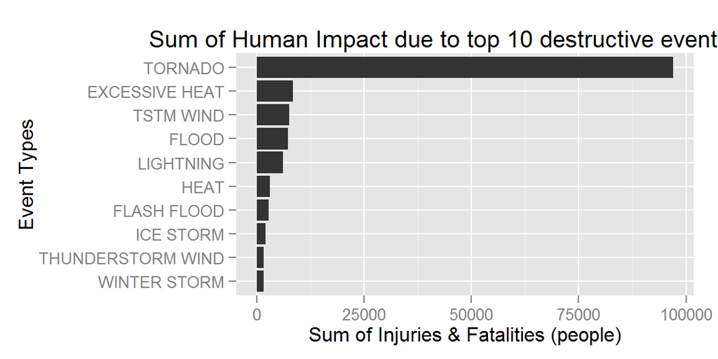

```r
plotHuman <- ggplot(stormDataHumanByType, aes(x = reorder(EVTYPE, totalHuman), y=totalHuman)) +
  geom_bar(stat = "identity") +
  ggtitle("Sum of Human Impact due to top 10 destructive event types") +
  xlab("Event Types") + ylab("Sum of Injuries & Fatalities (people)")+coord_flip()
print(plotHuman)
```

### 2. Across the United States, which types of events have the greatest economic consequences?

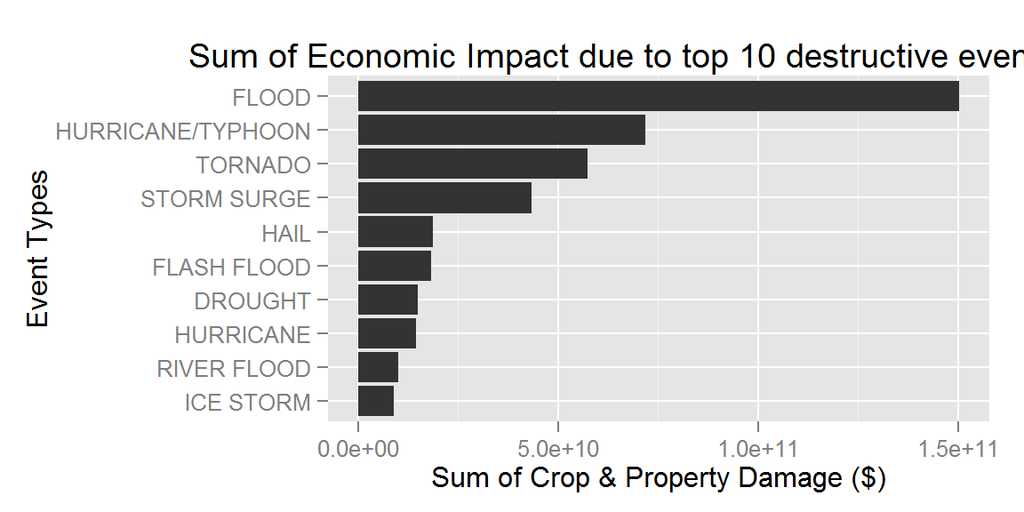

```r
plotEcon <- ggplot(stormDataEconomicByType, aes(x = reorder(EVTYPE, totalEconomic), y=totalEconomic)) +
  geom_bar(stat = "identity") +
  ggtitle("Sum of Economic Impact due to top 10 destructive event types") +
  xlab("Event Types") + ylab("Sum of Crop & Property Damage ($)")+coord_flip()
print(plotEcon)
```